# HW 02

Author

Cat Xia

Install Packages

```r
if (!require("pacman"))
  install.packages("pacman")

pacman::p_load(tidyverse, here, glue, scales, ggridges, dsbox, fs, janitor, ggforce, palmerpenguins, showtext, grid)

ggplot2::theme_set(ggplot2::theme_minimal())
options(width = 65)
knitr::opts_chunk$set(
  fig.width = 7,
  fig.asp = 0.618,
  fig.retina = 3,
  fig.align = "center",
  api = 300
)
```

## 1 - A new day, a new plot, a new geom

```r
#stores new col in df
edibnb <- edibnb |>

  #creates new column based on median of neighborhood groupings. Ignores NA to allow for median values other than NA
  group_by(neighbourhood) |>
  mutate(med_review = median(review_scores_rating, na.rm = TRUE)) |>
  ungroup() |>

  #re-orders the neighbourhoods so that when graphed, it is by median rating. Also turns NA into other/unknown
  mutate(neighbourhood = fct_reorder(neighbourhood, med_review),
         #directed to documentation (https://forcats.tidyverse.org/reference/fct_reorder.html) through various slack overflow
         neighbourhood = fct_explicit_na(neighbourhood, na_level = "Other/Unknown"),
        #attempted with replace_na() but unable to figure out why it didn't work. Consulted AI on why it didn't work and realized that neighborhood was in the wrong class. Directed to fct_explicit_na and code written based off forcats documentation. (https://forcats.tidyverse.org/reference/fct_explicit_na.html)

        #differentiates the NA from not NA
        nei_color = if_else(neighbourhood == "Other/Unknown", "grey", "black"))

#used for numbers referred to in the explanation
table(edibnb$neighbourhood)
```

```
    Haymarket     Newington      Old Town     Southside
         1026           439          1283           481
    Tollcross   Cannonmills         Leith     Marchmont
          270           485          3134           730
     New Town   Stockbridge      West End   Bruntsfield
         1058           587           822           290
  Morningside Other/Unknown
          346          2294
```

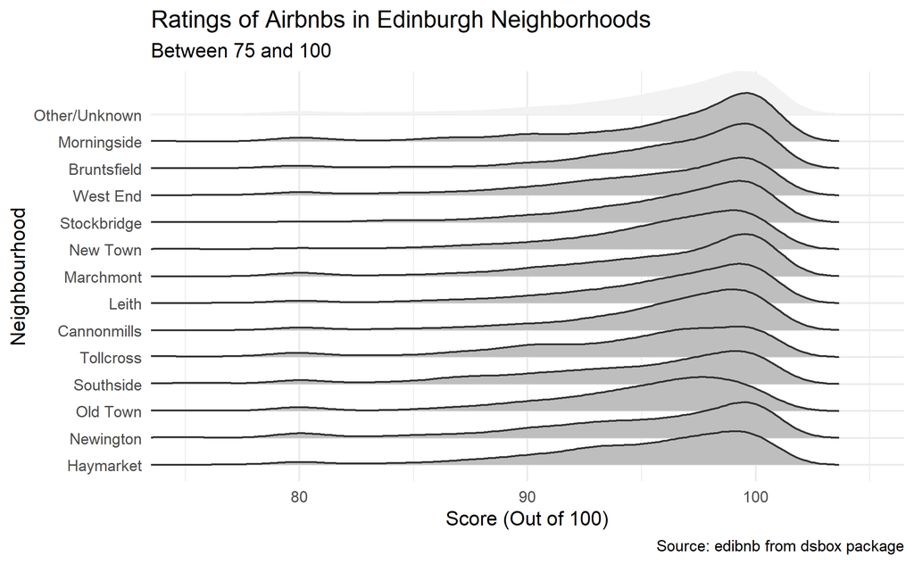

```r
edibnb |>
  #assigns neighbourhood to y because density ridges require categorical variables
  ggplot(aes(x = review_scores_rating, y = neighbourhood)) +
  geom_density_ridges(aes(fill = nei_color, color = nei_color)) +

  #Zooms in to 75-105 because variation is difficult to see 0-105
  coord_cartesian(xlim = c(75, 105)) +

  scale_fill_manual(values = c("grey", "grey95")) +
  scale_color_manual(values = c("grey20", "grey95")) +

  labs(
    x = "Score (Out of 100)",
    y = "Neighbourhood",
    title = "Ratings of Airbnbs in Edinburgh Neighborhoods",
    subtitle = "Between 75 and 100",
    caption = "Source: edibnb from dsbox package"
  ) +
  #gets rid of legend
  guides(fill = "none", color = "none") +
  theme_minimal()
```

The graph shows the density of ratings for Edinburgh airbnbs based on Neighborhood, starting from the highest median rated neighborhoods to the lowest. The graph only looks at the density of ratings that range from 75 to 100 due to the low volume of ratings below 75 which makes it harder to see comparisons clearly. Most Airbnbs are rated similarly in Edinburgh irregardless of neighboorhood, around 95 to 100, with the highest median (Morningside) only beating out the lowest median (Haymarket) by less than 5 points. NA ended up being the highest rated as well as having the second highest number of variables (2294), though because the neighborhood is data is missing, it is impossible to draw any conclusions from this.

I kept the variable in because it is a significant number of data points to ignore but colored it faintly so that it does not distract from the information I want to show.

## 2 - Foreign Connected PACs

```r
# get a list of files with "Foreign Connected PAC" in their names
list_of_files <- dir_ls(path = "data", regexp = "Foreign Connected PAC")

# read all files and row bind them
# keeping track of the file name in a new column called year
pac <- read_csv(list_of_files, id = "year")
```

```r
pac <- pac |>
  #cleans text and col titles
  clean_names() |>
  mutate(
    #takes later year (out of the 2) and turns into an int
    year = as.integer(parse_number(year) + 1), #*
    #turns contribution from char to double
    dems = as.numeric(gsub("[$,]", "", dems)), #**
    repubs = as.numeric(gsub("[$,]", "", repubs))) |>

  #separates column into two columns (where extra / are merged)
  separate_wider_delim(cols = country_of_origin_parent_company, delim = "/", names = c("country_of_origin", "parent_company"), too_many = "merge") |> #***

  #removes column from dataframe(df)
  subset(select = -total) #****

#glimpse left to compare it to hw for ease of grading
glimpse(pac)
```

```
Rows: 2,394
Columns: 6
$ year               <int> 2000, 2000, 2000, 2000, 2000, 2000, …
$ pac_name_affiliate <chr> "7-Eleven", "ABB Group", "Accenture"…
$ country_of_origin  <chr> "Japan", "Switzerland", "UK", "UK", …
$ parent_company     <chr> "Ito-Yokado", "Asea Brown Boveri", "…
$ dems               <dbl> 1500, 17000, 23000, 12500, 2000, 100…
$ repubs             <dbl> 7000, 28500, 52984, 26000, 0, 500, 1…
```

**Citations:**

* parse_number from textbook, take advantage of 1 year span for each file to get the correct year  
** read from https://stackoverflow.com/questions/50164340/negative-currency-values-using-parse-number-in-readr-r  
*** read https://stackoverflow.com/questions/76167485/how-to-use-str-split-fixed-to-split-a-column-while-removing-the-original-column for inspiration, code from documentation  
**** https://stackoverflow.com/questions/6286313/remove-an-entire-column-from-a-data-frame-in-r

```r
pivot_pac <- pac |>
  #pivots dems and repubs only to party (doesn't use ! in cols to not also pivot the rest)
  pivot_longer(cols = c(dems, repubs), names_to = "party", values_to = "amount") |>
  #changes the party to be capitalized and the full word.
  mutate(party = if_else(party == "dems", "Democrat", "Republican"))

#glimpse left for ease of grading
glimpse(pivot_pac)
```

```
Rows: 4,788
Columns: 6
$ year               <int> 2000, 2000, 2000, 2000, 2000, 2000, …
$ pac_name_affiliate <chr> "7-Eleven", "7-Eleven", "ABB Group",…
$ country_of_origin  <chr> "Japan", "Japan", "Switzerland", "Sw…
$ parent_company     <chr> "Ito-Yokado", "Ito-Yokado", "Asea Br…
$ party              <chr> "Democrat", "Republican", "Democrat"…
$ amount             <dbl> 1500, 7000, 17000, 28500, 23000, 529…
```

```r
yearly_contr_uk <- pivot_pac |>
  #groups by year and political party (gives final tibble with 3 columns)
  group_by(year, party) |>
  #filters for UK PACs
  filter(country_of_origin == "UK") |>
  #Calculates total for each year and each political party
  summarise(contribution = sum(amount))

#glimpse left for ease of grading
glimpse(yearly_contr_uk)
```

```
Rows: 24
Columns: 3
Groups: year [12]
$ year         <int> 2000, 2000, 2002, 2002, 2004, 2004, 2006, …
$ party        <chr> "Democrat", "Republican", "Democrat", "Rep…
$ contribution <dbl> 975725, 2057518, 1046183, 2002772, 1188801…
```

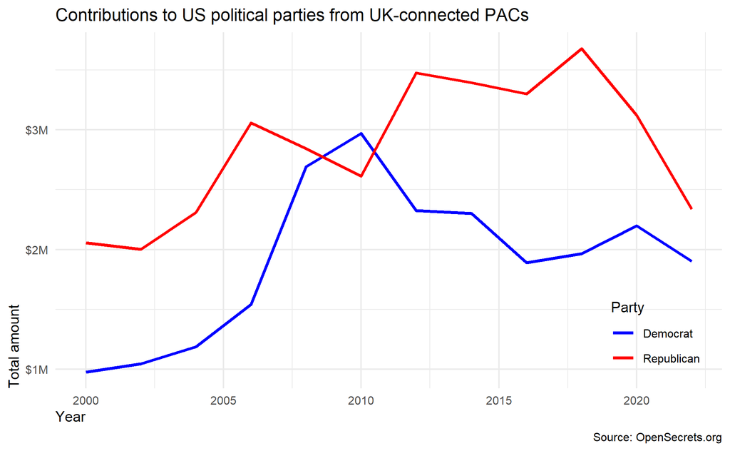

```r
yearly_contr_uk |>
  ggplot(aes(x = year, y = contribution, color = party)) +
  geom_line(size = 1) +
  #color to match traditional political party colors
  scale_color_manual(values = c("blue", "red")) +
  labs(
    x = "Year",
    y = "Total amount",
    title = "Contributions to US political parties from UK-connected PACs",
    color = "Party",
    caption = "Source: OpenSecrets.org"
  ) +
  #changes y labels to be dolar numbers rather than doubles
  scale_y_continuous(labels = label_dollar(scale = 1/1000000, suffix = "M")) +
  theme_minimal() +
  theme(
    #moves axis labels to bottom left and legend to bottom right
    axis.title.x = element_text(hjust = 0), #*
    axis.title.y = element_text(hjust = 0),
    legend.position = c(0.9, 0.15),
    #text in reference graph seems smaller than usual so text is decreased here as well
    text = element_text(size = 10) #**
  )
```

**Citations**

*https://www.sthda.com/english/wiki/ggplot2-title-main-axis-and-legend-titles **https://stackoverflow.com/questions/18486459/change-the-font-size-of-a-ggplot-chart

```r
#code copied from above with filter changed to canada
yearly_contr_ca <- pivot_pac |>
  group_by(year, party) |>
  filter(country_of_origin == "Canada") |>
  summarise(contribution = sum(amount))

glimpse(yearly_contr_ca)
```

```
Rows: 24
Columns: 3
Groups: year [12]
$ year         <int> 2000, 2000, 2002, 2002, 2004, 2004, 2006, …
$ party        <chr> "Democrat", "Republican", "Democrat", "Rep…
$ contribution <dbl> 66890, 137425, 92475, 118900, 99000, 17502…
```

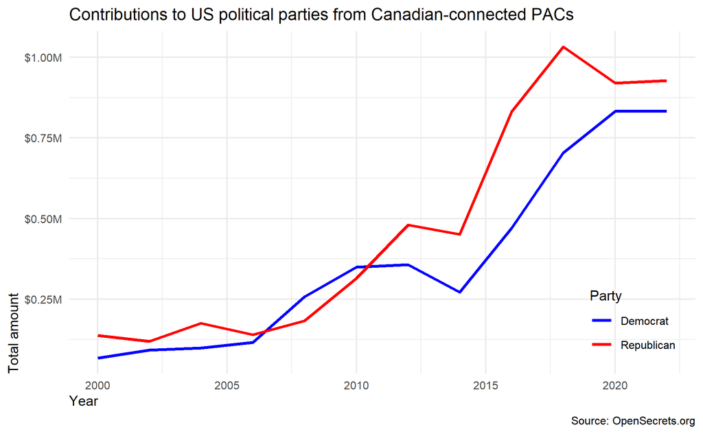

```r
#Code copied from above with title changed to reference Canada
yearly_contr_ca |>
  ggplot(aes(x = year, y = contribution, color = party)) +
  geom_line(size = 1) +
  scale_color_manual(values = c("blue", "red")) +
  labs(
    x = "Year",
    y = "Total amount",
    title = "Contributions to US political parties from Canadian-connected PACs",
    color = "Party",
    caption = "Source: OpenSecrets.org"
  ) +
  scale_y_continuous(labels = label_dollar(scale = 1/1000000, suffix = "M")) +
  theme_minimal() +
  theme(
    axis.title.x = element_text(hjust = 0), #*
    axis.title.y = element_text(hjust = 0),
    legend.position = c(0.9, 0.15),
    text = element_text(size = 10) #**
  )
```

## 3 - Median housing prices in the US

```r
med_housing_loc <- here("data", "median-housing.csv")
recess_loc <- here("data", "recessions.csv")
median_housing <- read.csv(med_housing_loc)
recessions <- read.csv(recess_loc)
```

```r
median_housing <- median_housing |>
  #renames variables
  rename(date = DATE, price = MSPUS)|>
  #changes date from char to ymd format and price into integer
  mutate(
    date = ymd(date),
    price = as.integer(price))
```

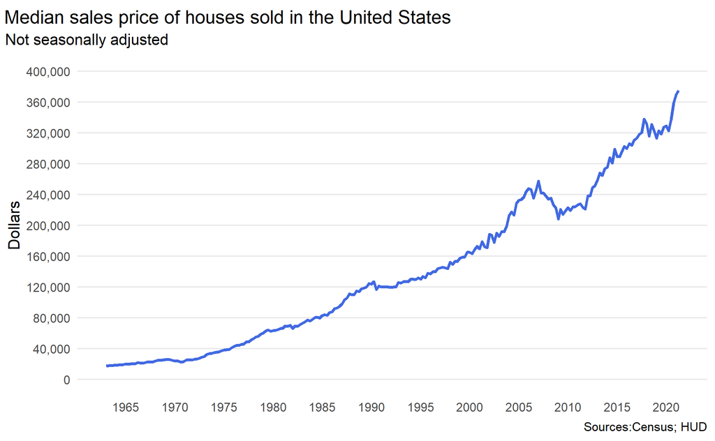

```r
median_housing |>
  ggplot(aes(x = date, y = price)) +
  geom_line(size = 1, color = "royalblue") + #*

  #labels y with comma rather than exponent, breaks by 40,000
  scale_y_continuous(label = comma, breaks = seq(0, 400000, by = 40000)) +

  #renames x tick marks and breaks them per 5 years
  scale_x_date(date_breaks = "5 years", date_labels = "%Y") + #**

  #fixes issue with top y axis mark not showing (ie 400,000)
  coord_cartesian(ylim = c(0, 400001)) +
  labs(
    title = "Median sales price of houses sold in the United States",
    subtitle = "Not seasonally adjusted",
    y = "Dollars",
    x = NULL,
    caption = "Sources:Census; HUD"
  ) +
  theme(
    #matches text size of graph
    text = element_text(size = 11),

    #moves title and subtitle to far left
    plot.title = element_text(hjust = -0.4, vjust = .5), #***
    plot.subtitle = element_text(hjust = -0.155),

    #takes out x axis lines and inbetween y axis lines
    panel.grid.major.x = element_blank(),
    panel.grid.minor.x = element_blank(),
    panel.grid.minor.y = element_blank()
  )
```

**Citations**

* https://www.nceas.ucsb.edu/sites/default/files/2020-04/colorPaletteCheatsheet.pdf ** confused with scale_x_continous(n.breaks) was not working. Consulted Ai which pointed me to scale_x_date. Code created by self through referring to documentation  
** https://ggplot2.tidyverse.org/reference/scale_date.html  
*** inspired to use negative placement values by https://stackoverflow.com/questions/25401111/left-adjust-title-in-ggplot2-or-absolute-position-for-ggtitle

```r
housing_start = as.Date("1963-01-01") #*
housing_end = as.Date("2021-12-31")

bounded_recession <- recessions |>
  clean_names() |>
  mutate(peak = ymd(peak),
         trough = ymd(trough),
         in_bounds = if_else(peak >= housing_start & trough <= housing_end, TRUE, FALSE)) |>
  filter(in_bounds == TRUE)

bounded_recession
```

```
        peak     trough in_bounds
1 1969-12-01 1970-11-01      TRUE
2 1973-11-01 1975-03-01      TRUE
3 1980-01-01 1980-07-01      TRUE
4 1981-07-01 1982-11-01      TRUE
5 1990-07-01 1991-03-01      TRUE
6 2001-03-01 2001-11-01      TRUE
7 2007-12-01 2009-06-01      TRUE
8 2020-02-01 2020-04-01      TRUE
```

**Citations**

*inspired to make separate variables from https://www.r-bloggers.com/2024/02/how-to-check-if-date-is-between-two-dates-in-r/

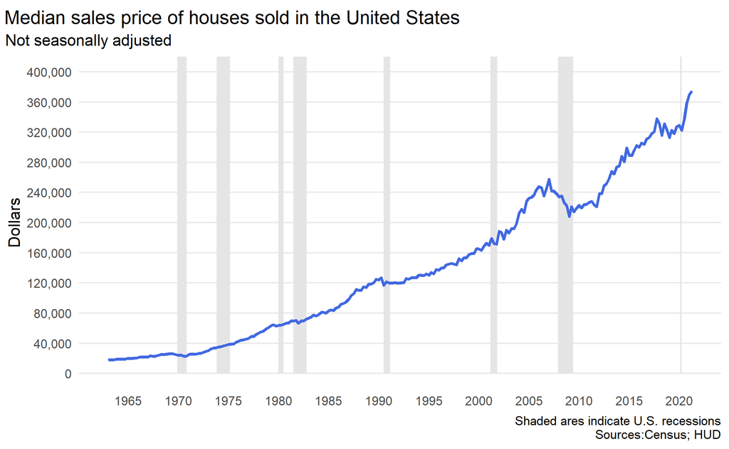

```r
median_housing |>
  ggplot(aes(x = date, y = price)) +
  #creates rectangles for recession
  geom_rect(data = bounded_recession,
            aes(xmin = peak,
                xmax = trough,
                #y goes to infinity
                ymin = 0, ymax = Inf,
                y = NULL, x = NULL), fill = "grey90") +

  geom_line(size = 1, color = "royalblue") +
  scale_y_continuous(label = comma, breaks = seq(0, 400000, by = 40000)) +
  scale_x_date(date_breaks = "5 years", date_labels = "%Y") +
  coord_cartesian(ylim = c(0, 400001)) +
  labs(
    title = "Median sales price of houses sold in the United States",
    subtitle = "Not seasonally adjusted",
    y = "Dollars",
    x = NULL,
    #add newline to caption
    caption = "Shaded ares indicate U.S. recessions\nSources:Census; HUD"
  ) +
  theme(
    text = element_text(size = 11),
    plot.title = element_text(hjust = -0.4, vjust = .5),
    plot.subtitle = element_text(hjust = -0.155),
    panel.grid.major.x = element_blank(),
    panel.grid.minor.x = element_blank(),
    panel.grid.minor.y = element_blank()
  )
```

```r
#beginning and end of dates
date_beg = as.Date("2019-01-01")
date_end = as.Date("2021-01-01")

subset_med_house <- median_housing |>
  #filter for housing from 2019-2020
  filter(date >= date_beg & date < date_end) |>

  #use lubridate to extract year and quater into their own columns
  mutate(
    year = year(date),
    quarter = quarter(date), #from lubridate documentation
    quarter = paste0(year, "Q", quarter)
  )
glimpse(subset_med_house)
```

```
Rows: 8
Columns: 4
$ date    <date> 2019-01-01, 2019-04-01, 2019-07-01, 2019-10-01…
$ price   <int> 313000, 322500, 318400, 327100, 329000, 322600,…
$ year    <dbl> 2019, 2019, 2019, 2019, 2020, 2020, 2020, 2020
$ quarter <chr> "2019Q1", "2019Q2", "2019Q3", "2019Q4", "2020Q1…
```

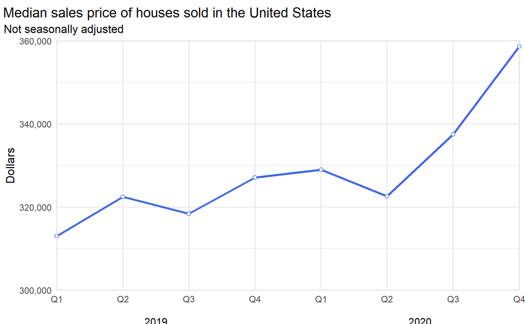

```r
subset_med_house |>
  #group allows line to go from point to point on a discrete x variable
  ggplot(aes(x = quarter, y = price, group = 1)) +
  #creates a line graph
  geom_line(size = 1, color = "royalblue") +
  #creates the points for each quarter. shape 21 is the filled in circle
  geom_point(color = "royalblue", shape = 21, fill = "white") +

  #creates the y axis labels and x axis labels
  scale_y_continuous(label = comma, breaks = c(300000, 320000, 340000, 360000)) +
  scale_x_discrete(labels = c("Q1", "Q2","Q3","Q4", "Q1", "Q2","Q3","Q4")) + #*

  #sets the coordinates and allows for text to go out of bounds (for annotations)
  #keeps grid within coordinate limits
  coord_cartesian(ylim = c(300000,360000), clip = "off", expand = FALSE) +

  #annotates the 2019 and 2020
  #**
  annotation_custom(textGrob("2019", gp = gpar(fontsize = 10)),xmin="2019Q2",xmax="2019Q3",ymin=290000,ymax=295000) +
  annotation_custom(textGrob("2020", gp = gpar(fontsize = 10)),xmin="2020Q2",xmax="2020Q3",ymin=290000,ymax=295000) +

  #labels, empty caption added to view 2019 2020 annotations
  labs(
    title = "Median sales price of houses sold in the United States",
    subtitle = "Not seasonally adjusted",
    y = "Dollars",
    x = NULL,
    caption = ""
  ) +

  #added border and moved title text to the correct position
  theme(
    text = element_text(size = 11),
    plot.title = element_text(hjust = -0.4, vjust = .5),
    plot.subtitle = element_text(hjust = -0.155),
    panel.border = element_rect(color = "grey90", fill = NA)
  )
```

**Citations**  
* Inspired by slack homework discussion  
** inspired from https://stackoverflow.com/questions/31079210/how-can-i-add-annotations-below-the-x-axis-in-ggplot2

## 4 - Expect More. Plot More.

[figure not shown]

```r
#making a tibble with x, y, radius, and color value
#3 circles on top of each other
x0 = c(1,1,1)
y0 = c(1,1,1)
r = c(3,2,1)
mycolor = c("r", "w","y")
circles <- tibble(x0, y0, r, mycolor)

circles |>
  #assigns x to x, y to y, r to r, color to both fill and color to get the borders as well
  ggplot(aes(x0 = x0, y0 = y0, r = r, fill = mycolor, color = mycolor)) +
  geom_circle() + #*
  scale_fill_manual(values = c("#CC0000", "white", "#cc0000")) +
  scale_color_manual(values = c("#CC0000", "white", "#cc0000")) +
  coord_fixed() +
  labs(
    x = NULL,
    y = NULL,
    caption = "TARGET ®" #got trademark through copy and pasting into the text though I think there is a harder way to do it that requires more coding? Not sure why that worked.
  ) +
  #clear the background
  theme_void()+
  #adjusts the Target sign
  theme(
    legend.position = "none",
    text = element_text(family = "helvetica", color = "#CC0000", face = "bold", size = 35),
    plot.caption = element_text(hjust = 0.5)
  )
```

**Citations**  
*https://www.rdocumentation.org/packages/ggforce/versions/0.4.2/topics/geom_circle  
Got color from https://www.brandcolorcode.com/target  
Most code was consulted through tidyverse documentation for theme()

After playing around with geom_circle, I decided to do three overlapping circles where the inner circles are on top of the outer ones. I used coord_fixed to make sure that the circles stay even. At first, I had some issues with getting the inner circle to be red. I assiged both the outside and inside circle to be the same color variable but I was unable to figure out why the innermost circle was moved underneath the white circle. I realized that I could just double assign any color to be the same so I set all the colors to different variables. Lastly, I had some issues with moving the title below the graph, so I switched to writing out the logo in caption instead.

## 5 - Mirror, mirror on the wall, who’s the ugliest of them all?

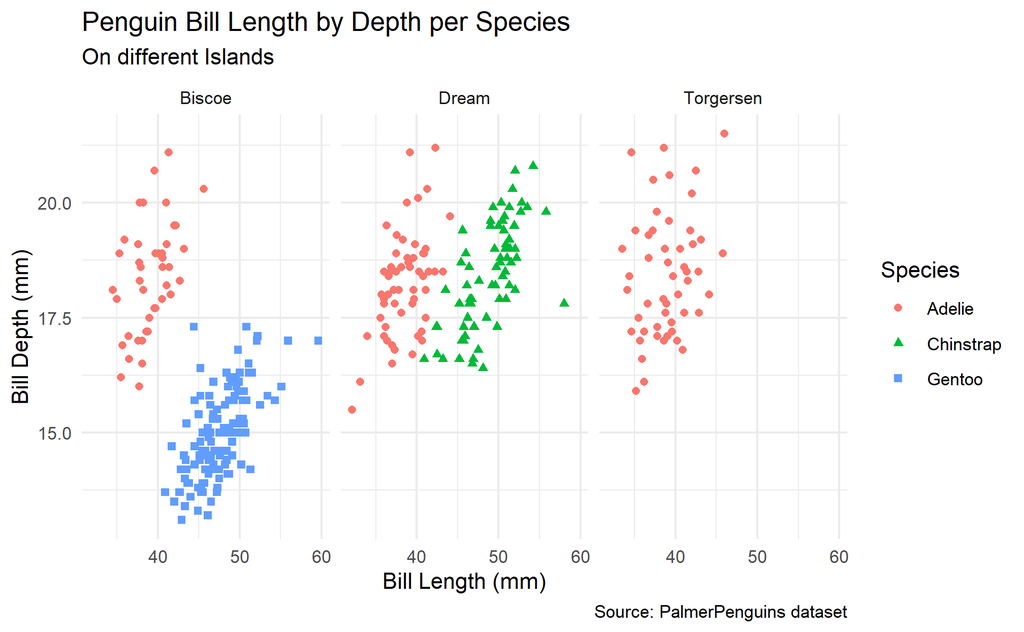

```r
penguins |>
  #assign x and y to length and depth and color by species
  ggplot(aes(x = bill_length_mm, y = bill_depth_mm, color = species, shape = species)) +

  #creates scatterplot
  geom_point() +

  #facets by island
  facet_wrap(~island) +

  #labels
  labs(
    x = "Bill Length (mm)",
    y = "Bill Depth (mm)",
    title = "Penguin Bill Length by Depth per Species",
    subtitle = "On different Islands",
    caption = "Source: PalmerPenguins dataset",
    shape = "Species",
    color = "Species"
  )
```

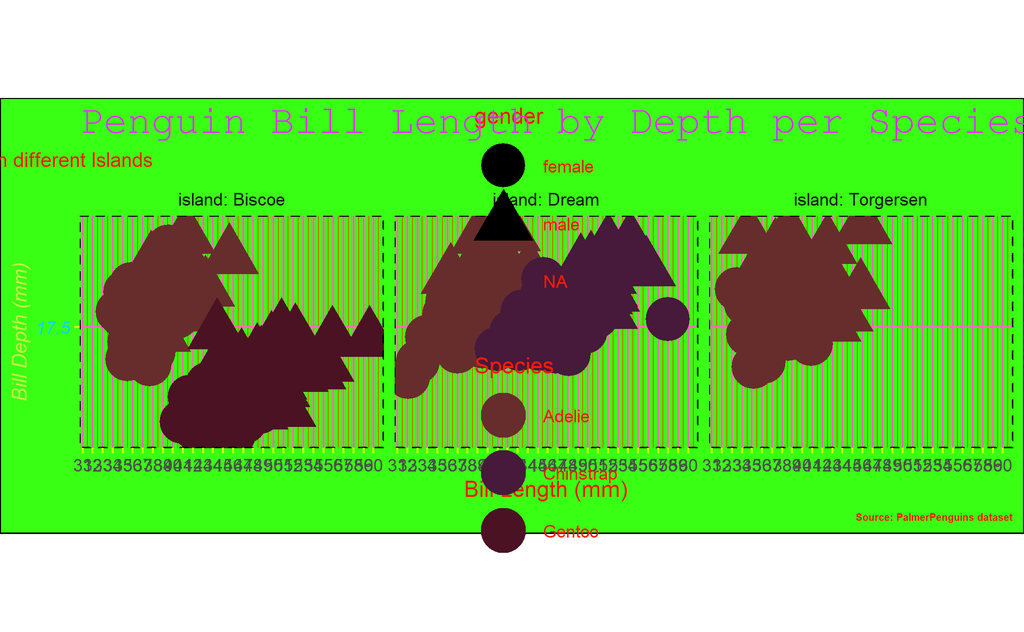

```r
penguins |>
  ggplot(aes(x = bill_length_mm, y = bill_depth_mm, color = species, shape = sex)) +
  #scatterplot size increase
  geom_point(size = 10) +
  #add unnecessary labels to the facet
  facet_wrap(~island, labeller = label_both) +
  labs(
    x = "Bill Length (mm)",
    y = "Bill Depth (mm)",
    title = "Penguin Bill Length by Depth per Species",
    subtitle = "On different Islands",
    caption = "Source: PalmerPenguins dataset",
    shape = "gender",
    color = "Species"
  ) +
  #add nonsensical breaks
  scale_x_continuous(n.breaks = 43) +
  scale_y_continuous(n.breaks = 2) +
  #adjust colors to be hard to read
  scale_color_manual(values = c("#672d2d", "#47193b", "#4b1223")) +
  coord_fixed(ratio = 2.5) +
  theme(
    #add color elements that make it hard to distinguish on top of the background, inconsistent font and typeface and size. Legend Position is unreadable but I ended up keeping it there because I thought it was funny.
    plot.background = element_rect(fill = "#39FF14"),
    text = element_text(color = "#ff1a00"),
    axis.ticks = element_line(color = "#CFFF04"),
    panel.grid.major = element_line(color = "#FF69B4"),
    panel.grid.minor = element_line(color = "#C76E00"),
    legend.position = c(0.5,0.5),
    plot.title = element_text(color = "#E92EFB", family = "mono", size = 19.5, hjust = 0),
    axis.title.y = element_text(face = "italic", color ="#C7EA46", size = 10),
    axis.text.y = element_text(face = "italic", color = "#04d9ff"),
    plot.subtitle = element_text(hjust = -0.13, size = 10),
    plot.caption = element_text(size = 5, face = "bold"),
    panel.border = element_rect(linetype = "dashed", fill = NA)
  )
```

All the code is through exploring theme() r documentation. All the hexcodes were found online through google image searches. I wanted to play with not only conflicting color and size, but also unreadable and annoying elements and unclear formatting. I had a lot of fun :)